# Youth Risk Behaviour Survey

Lawrence May

14/10/2020

## Youth Risk Behaviour Survey

1.) Build a classifier to predict labels r from x with xgboost, and show the confusion matrix

(You will need to specify the objective function for multi-class prediction, and you will need to remove observations with missing label)

```r
library(xgboost)
load('/Users/lawrence/Google Drive/misc/UNI/Stats 369/a4/yrbs.rda')

x <- x[-c(which(is.na(r))),]  #remove values that are labeled NA
r<- r[!is.na(r)]

test<-sample(nrow(x),0.1*nrow(x))
test_r<-r[test]

train_r<-r[-test]
train_x<-sapply(x[-test,],as.numeric)   #Turn all the predictors to numeric form
test_x<-sapply(x[test,],as.numeric)


bst <- xgb.cv(data = train_x, label = train_r, max_depth = 2, eta = 1, nthread=2,nrounds = 50,nfold=10, num_class = 8,objective = "multi:softmax",lambda=1)
```

```r
bst.final<-xgboost(data = train_x, label = train_r, max_depth = 2, eta = 1, nrounds = 23, num_class = 8,objective = "multi:softmax")
```

```r
table(predict(bst.final,newdata=test_x)==test_r)
```

```
##
## FALSE  TRUE
##   704   822
```

```r
table(predict(bst.final,newdata=test_x)==test_r)[2]/length(test_r)
```

```
##      TRUE
## 0.5386632
```

```r
unique(predict(bst.final,newdata=test_x))
```

```
## [1] 4 2 5 6 1 7
```

The model only predicts classes 1,2,4,5,6 and 7. Classes 0 and 3 do not get predicted by the model. These are Native Americans/ Alaskan natives and Native Hawaiians/Other pacific islanders. This is possibly due to their relative small number of observations compared to the other races:

```r
"Num. observations:"
```

```
## [1] "Num. observations:"
```

```r
cat(" American Indian/Alaskan Native:",length(train_r[train_r==0]))
```

```
##  American Indian/Alaskan Native: 149
```

```r
cat(" Asian: ",length(train_r[train_r==1]))
```

```
##  Asian:  570
```

```r
cat(" Black/African American: ",length(train_r[train_r==2]))
```

```
##  Black/African American:  1516
```

```r
cat(" Native Hawaiian or other Pacific Islander: ",length(train_r[train_r==3]))
```

```
##  Native Hawaiian or other Pacific Islander:  88
```

```r
cat(" White: ",length(train_r[train_r==4]))
```

```
##  White:  6181
```

```r
cat(" Hispanic/Latino: ",length(train_r[train_r==5]))
```

```
##  Hispanic/Latino:  2116
```

```r
cat(" multiple race and Hispanic/Latino: ",length(train_r[train_r==6]))
```

```
##  multiple race and Hispanic/Latino:  2449
```

```r
cat(" multiple-race but not Hispanic/Latino: ",length(train_r[train_r==7]))
```

```
##  multiple-race but not Hispanic/Latino:  671
```

There are a lot fewer observations for both American Indians and native Hawaiians, therefore they are less likely to be the correct category in the training set. The tree likely picks up on this and classifies them as a class that has more observations. One way to fix this might be to look into prior and posterior probabilities and incorporate these into the model (as was done in the rpart tree lab with the autism data). Alternatively, for the next data collection more attention could be put on ensuring that each race is reasonably similarly represented in the data set.

```r
table(predict(bst.final,newdata=test_x),test_r)
```

```
##    test_r
##       0   1   2   3   4   5   6   7
##   1   0  14   2   0   3   2   9   1
##   2   1   5  58   1  18  17  36   9
##   4   8  22  42   4 583  69 127  38
##   5   2  12  26   3  29  86  54   7
##   6   3   4  23   4  33  75  81  13
##   7   0   0   0   0   2   0   0   0
```

2.) Describe and visualise which variables are most important in the prediction.

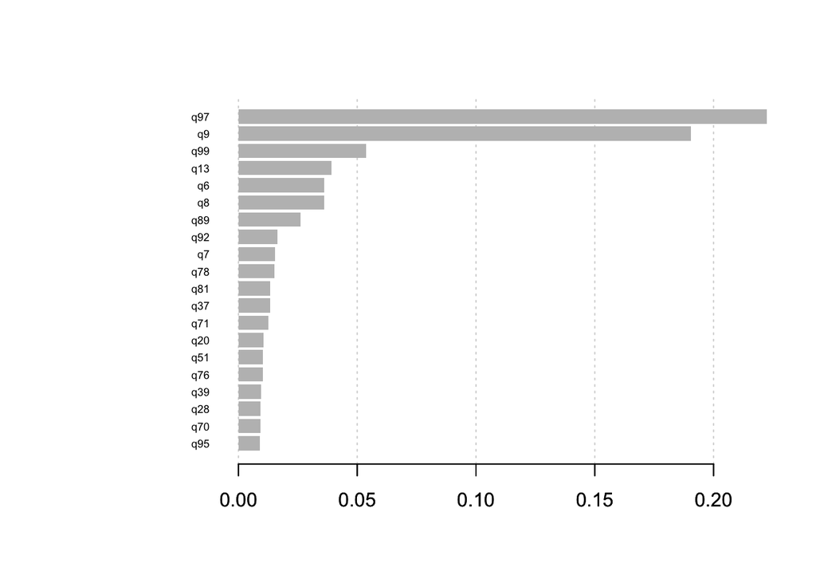

```r
imp<-xgb.importance(model=bst.final)
xgb.plot.importance(importance_matrix = imp, top_n = 20, measure = 'Gain')
```

```r
imp[1:10,]
```

```
##     Feature       Gain      Cover  Frequency Importance
##  1:     q97 0.22250384 0.06451599 0.04562044 0.22250384
##  2:      q9 0.19048293 0.01836383 0.01824818 0.19048293
##  3:     q99 0.05362293 0.02015767 0.01642336 0.05362293
##  4:     q13 0.03928201 0.02744067 0.02007299 0.03928201
##  5:      q6 0.03621084 0.06288457 0.04014599 0.03621084
##  6:      q8 0.03613319 0.02588502 0.01642336 0.03613319
##  7:     q89 0.02605603 0.04149102 0.03467153 0.02605603
##  8:     q92 0.01632870 0.01918199 0.01094891 0.01632870
##  9:      q7 0.01538507 0.02304076 0.03832117 0.01538507
## 10:     q78 0.01522391 0.01741089 0.01642336 0.01522391
```

```r
xgb.plot.tree(model=bst.final,trees = 0:3)
```

[interactive chart not shown]

This can be confirmed by the tree graph. While q97 (How often did you get sunburned) makes sense in predicting race, as perhaps native American or African American people are less likely to get sunburnt due to their skin composition, q9(How often do you wear a seatbelt) seems a little less relevant. This likely would reflect different attitudes among races towards seat belts.

3.) Task 3: Describe and display the relationships between the most important variables and the label categories – which category/categories is each of the most important variables useful for predicting? Can you produce a summary of the most distinctive predictors for each label category?

```r
train_binary_r_matrix<-matrix(nrow=length(train_r),ncol=8)
test_binary_r_matrix<-matrix(nrow=length(test_r),ncol=8)
#Each column represents the binaryised labels vector, where it equals 1 if the observation was the class that each column represents, and zero otherwise
for(i in c(1:8)){
  train_binary_r_matrix[,i]<-ifelse(train_r==i-1,1,0)
}

for(i in c(1:8)){
  test_binary_r_matrix[,i]<-ifelse(test_r==i-1,1,0)
}


#After doing cross-validation, 5 rounds seem to be sufficient
r_0<-xgboost(data = train_x, label = train_binary_r_matrix[,1], max_depth = 2, eta = 1, nrounds = 5)
r_1<-xgboost(data = train_x, label = train_binary_r_matrix[,2], max_depth = 2, eta = 1, nrounds = 5)
r_2<-xgboost(data = train_x, label = train_binary_r_matrix[,3], max_depth = 2, eta = 1, nrounds = 5)
r_3<-xgboost(data = train_x, label = train_binary_r_matrix[,4], max_depth = 2, eta = 1, nrounds = 5)
r_4<-xgboost(data = train_x, label = train_binary_r_matrix[,5], max_depth = 2, eta = 1, nrounds = 5)
r_5<-xgboost(data = train_x, label = train_binary_r_matrix[,6], max_depth = 2, eta = 1, nrounds = 5)
r_6<-xgboost(data = train_x, label = train_binary_r_matrix[,7], max_depth = 2, eta = 1, nrounds = 5)
r_7<-xgboost(data = train_x, label = train_binary_r_matrix[,8], max_depth = 2, eta = 1, nrounds = 5)
```

##Level 0: American Indian/Alaskan Native:

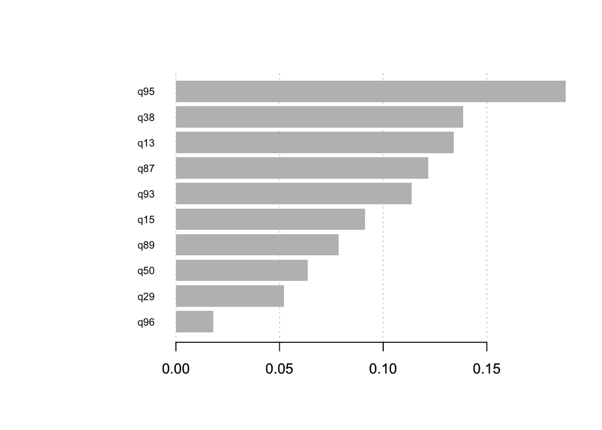

```r
imp<-xgb.importance(model=r_0)
xgb.plot.importance(importance_matrix = imp, top_n = 10, measure = 'Gain')
```

```r
xgb.plot.tree(model=r_0,trees = 0:2)
```

[interactive chart not shown]

```r
xgb.plot.tree(model=r_0,trees = 3:4)
```

[interactive chart not shown]

If the person had less than 5.5 sexual partners in their live, they are a lot more likely to be Native American.

##1=Asian

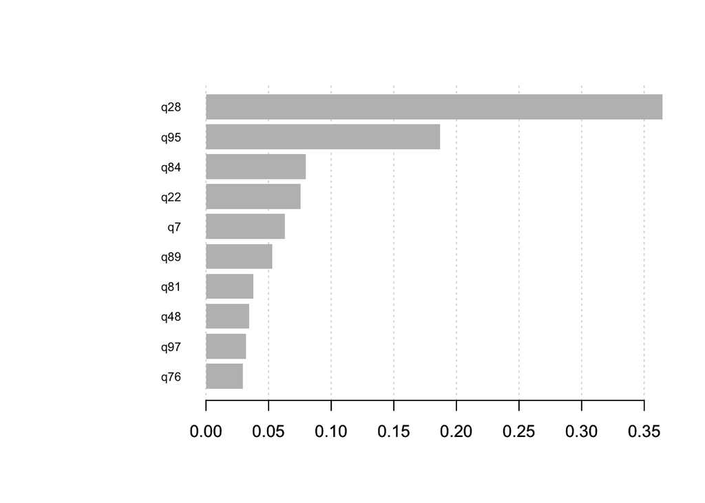

```r
imp<-xgb.importance(model=r_1)
xgb.plot.importance(importance_matrix = imp, top_n = 10, measure = 'Gain')
```

Q28:During the past 12 months, did you make a plan about how you would attempt suicide? seems to be by far the most important predictor of a student being Asian, followed by Q95. During the past 7 days, on how many days did you do exercises to strengthen or tone your muscles, such as push-ups, sit-ups, or weight lifting?

```r
xgb.plot.tree(model=r_1,trees = 0:1)
```

[interactive chart not shown]

2=Black/African American

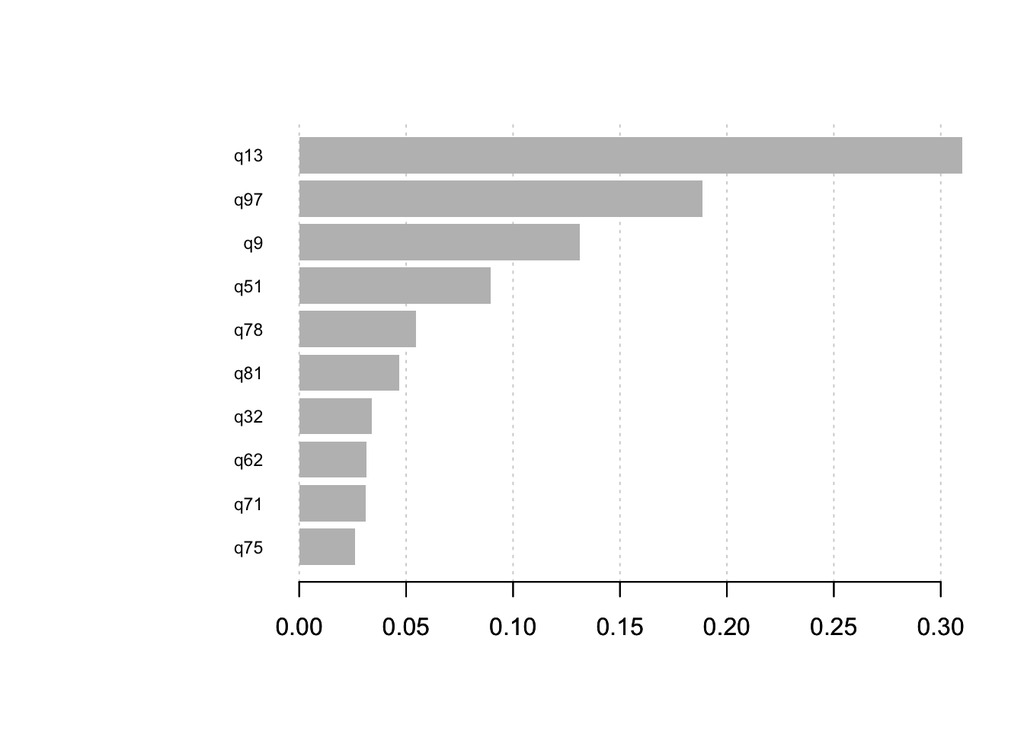

```r
imp<-xgb.importance(model=r_2)
xgb.plot.importance(importance_matrix = imp, top_n = 10, measure = 'Gain')
```

Q13. During the past 30 days, on how many days did you carry a weapon such as a gun, knife, or club? and Q97. During the past 12 months, how many times have you had a sunburn? were most significant in classifying a child to be black.

```r
xgb.plot.tree(model=r_2,trees = 0:1)
```

[interactive chart not shown]

3=Native Hawaiian or other Pacific Islander

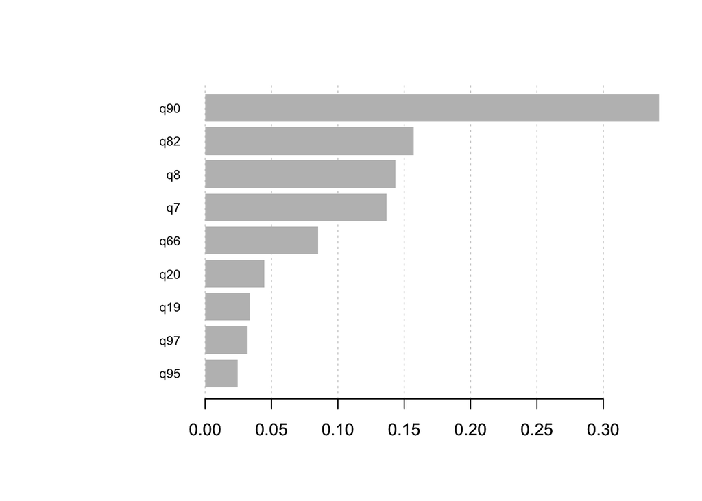

```r
imp<-xgb.importance(model=r_3)
xgb.plot.importance(importance_matrix = imp, top_n = 10, measure = 'Gain')
```

```r
xgb.plot.tree(model=r_3,trees = 0:1)
```

[interactive chart not shown]

4=White

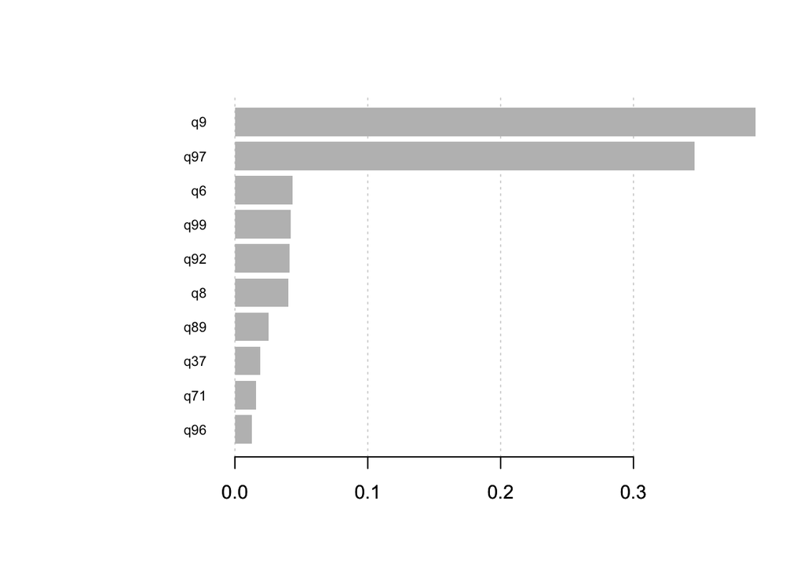

```r
imp<-xgb.importance(model=r_4)
xgb.plot.importance(importance_matrix = imp, top_n = 10, measure = 'Gain')
```

Q9. How often do you wear a seat belt when riding in a car driven by someone else? and Q97. During the past 12 months, how many times have you had a sunburn? were the most important predictors for a person being white.

```r
xgb.plot.tree(model=r_4,trees = 0:1)
```

[interactive chart not shown]

The tree identifies people being white by them always wearing seatbelts and being more prone to sunburn and being able to speak english well or very well (q99).

5=Hispanic/Latino

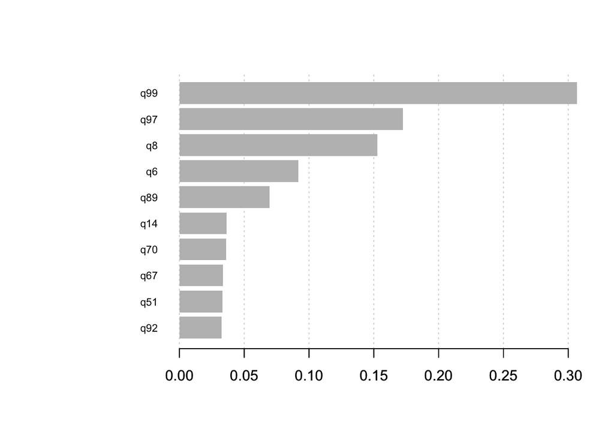

```r
imp<-xgb.importance(model=r_5)
xgb.plot.importance(importance_matrix = imp, top_n = 10, measure = 'Gain')
```

Q99. How well do you speak English? and Q8. When you rode a bicycle during the past 12 months, how often did you wear a helmet? and Q97. During the past 12 months, how many times have you had a sunburn? were most important in predicting a person to be latino.

```r
xgb.plot.tree(model=r_5,trees = 0:1)
```

[interactive chart not shown]

The most important variable for the tree to identify latinos is if they don’t speak English well or very well - sensible as in many cases Spanish might be their first language.

6=multiple race and Hispanic/Latino

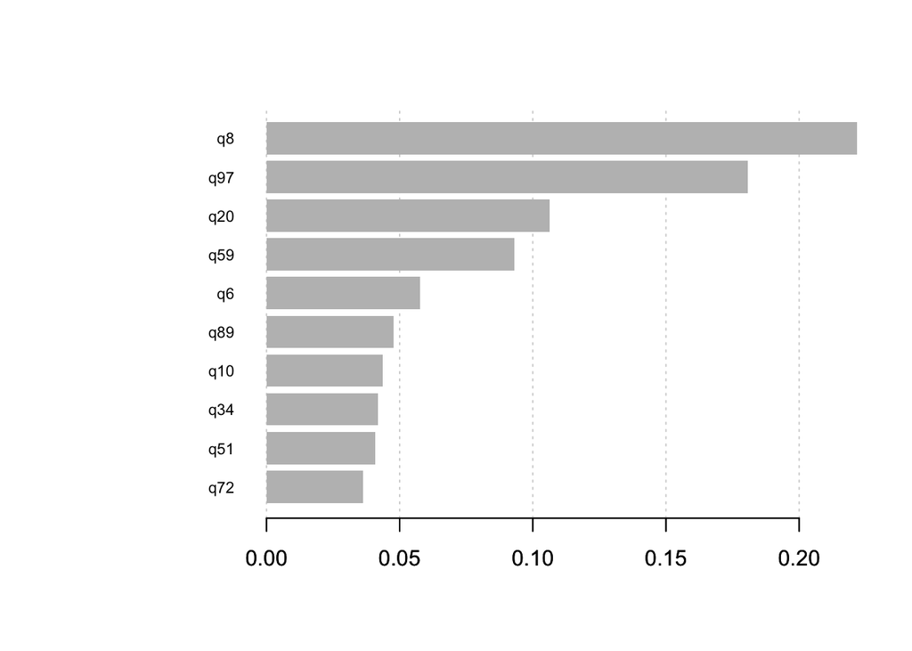

```r
imp<-xgb.importance(model=r_6)
xgb.plot.importance(importance_matrix = imp, top_n = 10, measure = 'Gain')
```

Likewise Q8. When you rode a bicycle during the past 12 months, how often did you wear a helmet? and Q97. During the past 12 months, how many times have you had a sunburn? were most important to predict category 6.

7=multiple-race but not Hispanic/Latino

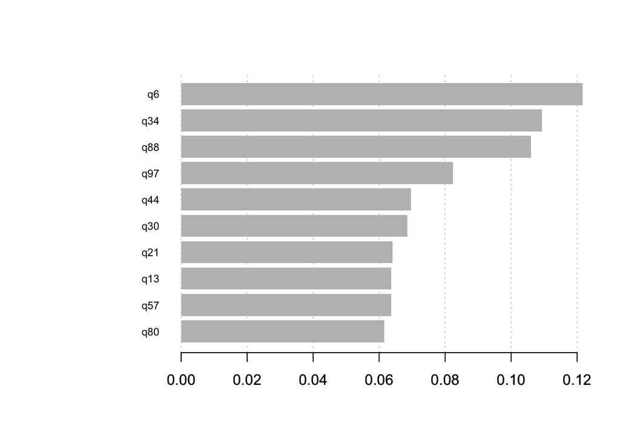

```r
imp<-xgb.importance(model=r_7)
xgb.plot.importance(importance_matrix = imp, top_n = 10, measure = 'Gain')
```

##Overall summary of relationship between most important variables and label categories

The second most important overall variable is q9 How often do you wear a seat belt when riding in a car driven by someone else? which the tree uses heavily to classify label category 4 (white) and to a lesser extend category 2 (black). This might reflect different cultural attitudes towards the wearing of seat belts among different ethnicities.

The third most important overall variable is q99 How well do you speak English? which the tree relied on heavily to classify label category 5 (Hispanic/Latino). This likely reflects Spanish instead of English being the first language for many Latino children.

4.) Task 4: Comment on whether (or not) task 3 would be ethically problematic if intended to be published, and for what reasons.

Task 3 would be ethically problematic to publish as it can lead to discrimination. For example, the most important variable for identifying black children is Q13:“During the past 30 days, on how many days did you carry a weapon such as a gun, knife, or club?” which directly feeds into many negative stereotypes surrounding African Americans. Likewise, Q90. “During the past 30 days, how did you usually use marijuana?” was the most important variable for identifying native Hawaiians.

This can lead to and reinforce all kinds of problems, from social stigma to being denied housing, jobs or other opportunities. Another reason it could be problematic is that it could lead to certain vulnerable groups to be taken advantage of. For example, if our findings indicate that a certain ethnic group is more likely to consume junk food and soft drinks, this could lead to junk food and soft drink companies specifically targeting this ethnic group, taking advantage of their tendency to consume these unhealthy foods and thereby only amplifying the problem. Another reason is that if a variable such as drug or alcohol abuse turns out to be a good predictor for a certain ethnicity category, this could lead to discrimination (possibly unintended) if this classifier is used for things such as job applications or mortgages.